# Week 02

Basic concepts

Dr. Peng Zhao

2020-09-17

## Q & A

Q1. Is R language a requirement for the assessments?

A1. No. The assessments, including the final exam, are problem-solving oriented. You are free to use any tool to solve the problems. However, some statistical problems are not easy to solve if you only use a pocket calculator or Excel. You have to learn at least one statistical tool. R, SPSS, and SAS are recommended.

Q2. Do I have to check in the attendance list every time?

A2. No. Although students’ engagement in class is of importance, this module does not check your attendance. Your marks are composed of the two courseworks (20 % + 20 %) and the final exam (60 %). On-site quizzes and discussions are not counted into your marks.

Q3. Do I have to do all the exercises?

A3. No. The exercises are only for your practice. Do not submit your answers.

Q4. Why cannot I see the BBB recordings after class?

A4. It depends on the BBB server’s status. Sometimes a recorded video appears in 5 minutes, sometimes in 5 hours or even longer. Be patient. If it does not appear on the second day after the class, email me and I will contact MITS.

Q5. What if I don’t like the role play for *The Manga Guide to Statistics*?

A5. Don’t take the role play too seriously. It is just for fun. The purpose of the role play is to make sure that you read the chapter of the book and distribute the information to others. You don’t have to be a professional actor. If you are really stressed for it, you could simply read the lines to the audience and it is fine.

## Ice breaking

- Role play: *The Manga Guide to Statistics*: Prologue
- Role play: *The Manga Guide to Statistics*: Data types

> Statistics is a study that estimates the status of a population by using information gained from samples.

> — Mr. Igarashi, *The Manga Guide to Statistics*

## Objectives

1. Learn the basic concepts in statistics.
2. Estimate the posibility of an event.
3. Understand the features of data types.

## Population and sample

**Population:**

the largest collection of entities for which we have an interest at a particular time

**Parameter:**

measures of the population, denoted by Greek letters (e.g., $\mu$ and $\sigma ^2$ for the population mean and variance)

**Sample:**

a subset of the population

**Statistic:**

measures of the sample, denoted by Roman letters (e.g., $\bar x$ and $s^2$ for the sample mean and variance)

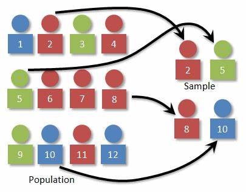

Population and sample

**Sample space:**

the set of all possible outcomes

**Event:**

a set of outcomes of interest

**Probability of an event:**

the relative frequency of this set of outcomes over an infinitely large number of trials

**Randomly sampling:**

a sampling technique in which each sample has an equal probability of being chosen.

Suppose you cook a pot of soup for you family. You add some salt into it. How do you know if the soup is salty enough for your family?

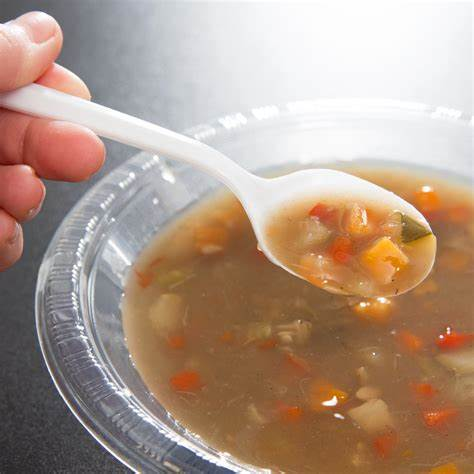

Sample a spoon of soup from a pot

Demo:

1. Use the sampling box for randomly choosing a group
2. the `sample()` function for randomly choosing a group

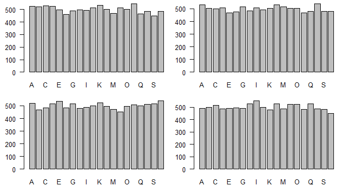

```r
groups <- LETTERS[1:20]
sample(groups, 1)
x <- replicate(10000,sample(groups, 1))
barplot(table(x), names.arg = names(x))
```

## Probability of an event

The probability of an event *E* denoted by *P(E)*, always satisfies $0 \le P(E) \le 1$.

If outcomes *A* and *B* are two events that cannot both happen (i.e., *A* and *B* are mutually exclusive or disjoint), then $P(A \text{ or } B) = P(A) + P(B)$.

- The symbol {} is used as shorthand for the phrase “the event”.
- $\{A \cup B\}$ is the event that either $A$ or $B$ occurs, or they both occur.
- $\{A \cap B\}$ is the event that both $A$ and $B$ occur simultaneously.
- $\bar{A},$ called the complement of $A,$ is the event that $A$ does not occur. Note, $P(\bar{A})=1-A$

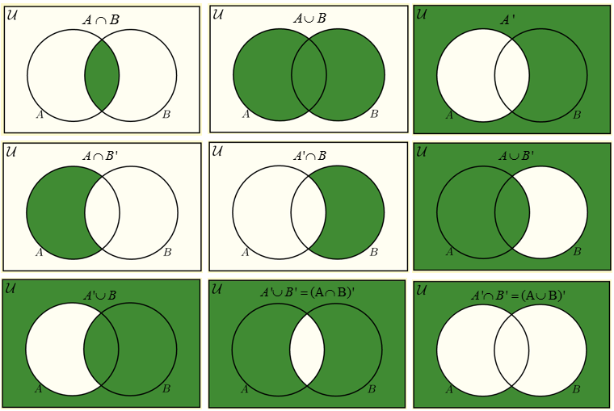

Set operations.

Demo: ENV203 Students data.

Download students203.csv from Week 01. What is the probability of the event that a randomly selected subject is male?

```r
env203 <- read.csv("data/students203.csv")
table(env203$Gender)
```

```
##
## Female   Male
##     38     12
```

```r
12 / ( 38 + 12)
```

```
## [1] 0.24
```

```r
table(env203$Gender)[2]
```

```
## Male
##   12
```

```r
nrow(env203)
```

```
## [1] 50
```

```r
table(env203$Gender)[2] / nrow(env203)
```

```
## Male
## 0.24
```

## Laws and Rules

### Multiplication Law

Definitions:

- $A$ and $B$ are independent events if $P(A \cap B)=P(A) \times P(B)$
- $A$ and $B$ are dependent events if $P(A \cap B) \neq P(A) \times P(B)$

Multiplication Law If $A_{1}, A_{2}, \ldots, A_{k}$ are mutually independent events, then

$$P\left(A_{1} \cap A_{2} \cap \cdots \cap A_{k}\right)=P\left(A_{1}\right) \times P\left(A_{2}\right) \times \cdots \times P\left(A_{k}\right)$$

Demo: The ENV203 students survey. What is the possibility that a randomly selected subject is male from North China?

```r
env203$Hometown <- c("South", "North")[env203$Hometown]
table(env203$Gender, env203$Hometown)
```

```
##
##          North South
##   Female    18    20
##   Male       3     9
```

```r
library("Epi")
stat.table(list(Gender, Hometown),
           data = env203,
           margins = c(TRUE, TRUE))
```

```
##  ---------------------------------
##          --------Hometown---------
##  Gender     North   South   Total
##  ---------------------------------
##  Female        18      20      38
##  Male           3       9      12
##
##  Total         21      29      50
##  ---------------------------------
```

```r
p_a_and_b <- 3 / 50
p_a_and_b
```

```
## [1] 0.06
```

$A$ is the event that a randomly selected subject is male.

$B$ is the event that a randomly selected subject is from North China.

```r
p_a <- table(env203$Gender)[2] / nrow(env203)
p_b <- table(env203$Hometown)[1] / nrow(env203)
p_a * p_b
```

```
##   Male
## 0.1008
```

$P(A \cap B) \neq P(A) \times P(B)$. Thus $A$ and $B$ are dependent events.

### Addition Law

For any two events $A$ and $B$,

$$P(A \cup B)=P(A)+P(B)-P(A \cap B)$$

Demo: The ENV203 students survey.

$A$ is the event that a randomly selected subject is male.

$B$ is the event that a randomly selected subject is from North China.

The possibility that a randomly selected subject is male or is from North China is $P(A \cup B)=P(A)+P(B)-P(A \cap B)$.

```r
p_a_or_b <- p_a + p_b - p_a_and_b
p_a_or_b
```

```
## Male
##  0.6
```

### Conditional probability

- The conditional probability of $B$ given $A$ is written as $P(B \mid A)$.

$$P(B \mid A)=\frac{P(B \cap A)}{P(A)} ; P(A) \neq 0$$

- If $A$ and $B$ are independent events, then

$$P(B \mid A)=P(B)=P(B \mid \bar{A})$$

- If $A$ and $B$ are dependent events, then

$$P(B \mid A) \neq P(B) \neq P(B \mid \bar{A})$$

Demo: The ENV203 students survey.

$A$ is the event that a randomly selected subject is male.

$B$ is the event that a randomly selected subject is from North China.

The possibility that a randomly selected subject is from North China given the subject is male is $P(B \mid A)=\frac{P(B \cap A)}{P(A)}$.

```r
p_b_given_a <- p_a_and_b / p_a
p_b_given_a
```

```
## Male
## 0.25
```

### Total Probability Rule

For any two events $A$ and $B$,

$$P(B)=P(B \mid A) \times P(A)+P(B \mid \bar{A}) \times P(\bar{A})$$

Derivation:

$B$ occurs with or without $A,$ so $P(B)=P(B \cap A)+P(B \cap \bar{A})$. From the definition of conditional probability, $P(B \cap A)=$ $P(B \mid A) \times P(A)$ and $P(B \cap \bar{A})=P(B \mid \bar{A}) \times P(\bar{A}) .$ Simple substitution gives the results.

A set of events $A_{1}, \ldots, A_{k}$ is exhaustive if at least one of the events must occur.

Let $A_{1}, \ldots, A_{k}$ be mutually exclusive and exhaustive events. The unconditional probability of $B, P(B),$ can be written as the weighted average of the conditional probabilities of $B$ given $A$.

$$P(B)=\sum_{i} P\left(B \mid A_{i}\right) \times P\left(A_{i}\right)$$

### Bayes’ Rule

$$P(B \mid A)=\frac{P(A \mid B) \times P(B)}{P(A \mid B) \times P(B)+P(A \mid \bar{B}) \times P(\bar{B})}$$

Derivation: From the definition of conditional probability,

$$\begin{array}{l}
P(B \mid A)=P(B \cap A) / P(A) \\
P(B \cap A)=P(A \mid B) \times P(B)
\end{array}$$

From the total probability rule,

$$P(A)=P(A \mid B) \times P(B)+P(A \mid \bar{B}) \times P(\bar{B})$$

Substitute (3) and (2) into (1).

## Greek and Roman letters

We use Greek letters $\mu$ and $\sigma$ as the population mean and standard deviation. Many Greek letters, such as $\Sigma, \Pi, \rho...$, appear in this statistics. Why?

- Greek civilization was the origin of Roman civilization.
- The population is the origin of a sample.

Greek alphabet list. Adapted from https://www.rapidtables.com/math/symbols/greek_alphabet.html

| Upper Case | Lower Case | English | Pronunciation |
| --- | --- | --- | --- |
| $\Alpha$ | $\alpha$ | a | Alpha |
| $\Beta$ | $\beta$ | b | Beta |
| $\Gamma$ | $\gamma$ | g | Gamma |
| $\Delta$ | $\delta$ | d | Delta |
| $\Epsilon$ | $\epsilon$ | e | Epsilon |
| $\Zeta$ | $\zeta$ | z | Zeta |
| $\Eta$ | $\eta$ | h | Eta |
| $\Theta$ | $\theta$ | th | Theta |
| $\Iota$ | $\iota$ | i | Iota |
| $\Kappa$ | $\kappa$ | k | Kappa |
| $\Lambda$ | $\lambda$ | l | Lambda |
| $\Mu$ | $\mu$ | m | Mu |
| $\Nu$ | $\nu$ | n | Nu |
| $\Xi$ | $\xi$ | x | Xi |
| $\Omicron$ | $\omicron$ | o | Omicron |
| $\Pi$ | $\pi$ | p | Pi |
| $\Rho$ | $\rho$ | r | Rho |
| $\Sigma$ | $\sigma$, $\varsigma$ | s | Sigma |
| $\Tau$ | $\tau$ | t | Tau |
| $\Upsilon$ | $\upsilon$ | u | Upsilon |
| $\Phi$ | $\phi$ | ph | Phi |
| $\Chi$ | $\chi$ | ch | Chi |
| $\Psi$ | $\psi$ | ps | Psi |
| $\Omega$ | $\omega$ | o | Omega |

* second lower case sigma letter is used in word final position

Demo: Guess what these words mean:

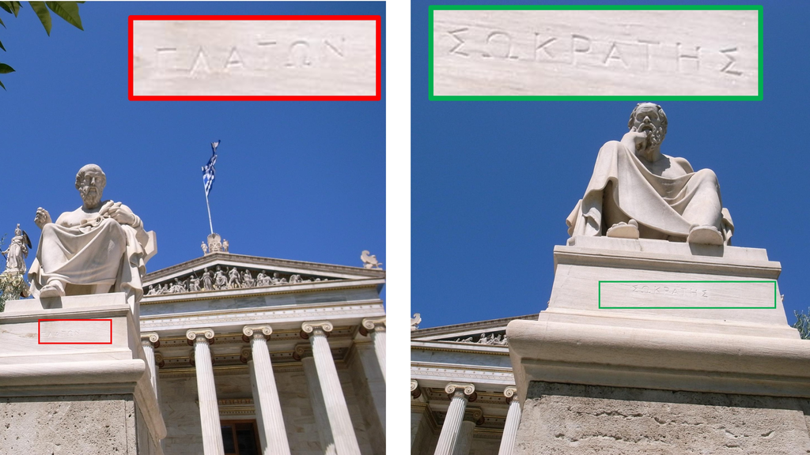

[figure not shown]

$\Zeta\eta\alpha\omega$ $\Pi\epsilon\nu\gamma$

1. Questions: Why do we use …
- $\Sigma$ in $\Sigma_{i = 1}^k x_i$ for $x_i + x_2 + ... + x_k$ ?
- $\Pi$ in $\Pi_{i = 1}^k x_i$ for $x_i \times x_2 \times ... \times x_k$ ?
- $\Delta$ in $\Delta t$ for $t_2- t_1$?
- $\eta$ for the mechanical efficiency?
- $\lambda$ for the wave length?
2. Write your names with Greek letters.
3. Write our university’s name with Greek letters.

## Data types

### Two data types

Normally, we treat data as two types:

- Qualitative data, or categorical data, place data in descriptive groups. e.g. home prefecture, Judo rank, weather…
  - Nominal variables have neither rank nor distance.
  - Ordinal variables have rank but no distance.
- Quantitative data, or numerical data, take numerical values. They have both rank and distance. e.g. temperature, weight…
  - Discrete variables often take on integers.
  - Continuous variables can take on any value.

Data types.

| Type | Sub-type | Rank | Distance | Examples |
| --- | --- | --- | --- | --- |
| qualitative (categorical) | nominal | no | no | sex, weather |
|  | ordinal | yes | no | preferences, grades |
| quantitative (numerical) | discrete | yes | yes | age, book quantity |
|  | continuous | yes | yes | weight, height |

Distinguish qualitative data and quantitative data with scale, which has two components:

- Rank is the ability to tell that one value is greater than another
- Distance is the ability to make sense of the “magnitude” of the distance between two values

Knowing the types of your data would help you choose the appropriate distribution to analyze you data, tables and graphs to present your data.

Demo: The data types in the ENV203 students’ survey

### Using software to check data types

```r
is.character()
is.integer()
is.numeric()
class()
mode()
typeof()
str()
```

Demo: check the object types of ENV203 students data.

### Converting data types

1. Reducing the scale of variables will result in a loss of information.  
   Example:
- height —> grouped into “> 1.3 m” and “$\le$ 1.3 m”
- wind rose. Download the wind.csv file. Open it in Excel or R. Plot a wind rose.

[figure not shown]

Windrose

The windrose graph convert wind speeds from m/s to intervals.

2. Add the scale of variables will be misleading.  
   Example:
- Table of the test grades
- Coding of the samples in the tce dataset (tce.csv in Week 01).

Table: Test grades

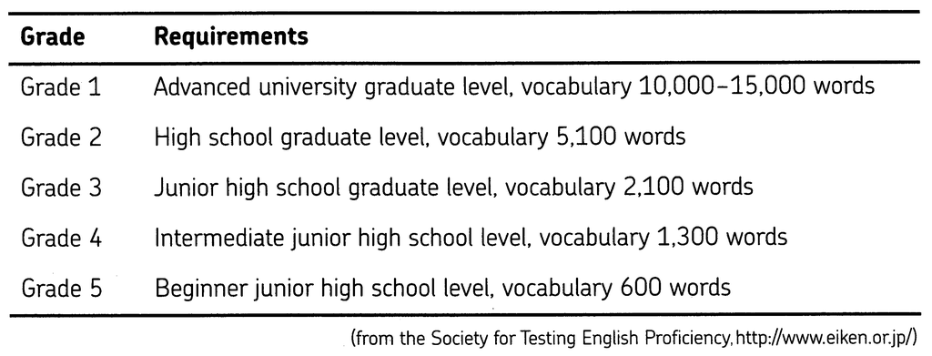

```r
tce <- read.csv("data/tce.csv")
```

### Using software to convert data types

```r
as.character()
as.integer()
as.numeric()
as.factor()
cut()
```

Demo: Converting the data types of ENV203 students survey.

## Assignments

- Read: Probability with Set Operations
- Read: R RStudio Basics
- Preapar for the role play by a randomly chosen group: *The Manga Guide to Statistics*: Numeric data

## Exercises

Find the following probabilities:

1. A randomly selected subject is female.
2. A randomly selected subject has a star sign of Leo.
3. A randomly selected subject is female with a star sign of Leo.
4. A randomly selected subject is female or has a star sign of Leo.
5. A randomly selected subject is female given that the star sign is Leo.

**Titanic**

RMS Titanic was a British passenger liner operated by the White Star Line that sank in the North Atlantic Ocean in the early morning hours of 15 April 1912, after striking an iceberg during her maiden voyage from Southampton to New York City. Of the estimated 2,224 passengers and crew aboard, more than 1,500 died, making the sinking one of modern history’s deadliest peacetime commercial marine disasters.

Find the following probabilities:

1. A randomly selected subject is a surviving girl from the 2nd class.
2. A randomly selected subject is a dead male crew.
3. A randomly selected subject is a woman or is from the 3rd class.
4. A randomly selected subject is a man given that he/she survived.
5. A randomly selected subject is a boy given that he/she is from the 1st class.

**EPA applicants**

A certain environmental protection agency received 25 applications for an opening in the water testing division. Of these applicants 10 are under 30 and 15 are over 30. Seventeen hold bachelor’s degrees only, and eight have master’s degrees. Of those under 30, six have master’s degrees. If a selection from among these 25 applicants is made at random, what is the probability that a person over 30 **or** a person with a master’s degree will be selected?

**New York air quality**

1. What is the the type of each column in the New York air quality dataset?
2. Add a new column “Month_English” as the month in English. What is the type of the new column? What is the difference between the column “Month” and “Month_English”?
3. Add a new column “Wind_group”, showing grouped wind speed as “0 - 2”, “2 - 5”, “5 - 10”, “> 10”.

**Groundwater TCE**

1. What are the the type of each column in the groundwater TCE dataset?
2. Add a new column “Well_name” as “A” for Well 1, “B” for Well 2, etc.. What is the type of the new column? What is the difference between the column “Well” and “Well_name”?
3. Add a new column “TCE_level” as “High” when the TCE concentration > 10, “Low” when the TCE concentration <= 5, and “Medium” for the rest. What is difference between the concentrations and the concentration levels?